# Water quality perception vs. reality in California

Caroline Condon, Sabine Loos, & Jenny Zhi

In this notebook, we pull together the data to make the infographics in our final DP3 project.

```r
# load libraries
suppressMessages(library(rgdal))
suppressMessages(library(rgeos))
suppressMessages(library(ggplot2))
suppressMessages(library(plotly))
suppressMessages(library(dplyr))
suppressMessages(library(ggrepel))
suppressMessages(library(extrafont))

# load fonts
suppressMessages(font_import(pattern = "OpenSans-Regular", prompt = F))
suppressMessages(loadfonts(device = "win"))
# load functions
source("functions/sp2gg.R") #read in function to convert to ggplot polygon
source("functions/PlottingFunctions.R") #themes for plots
```

```r
CA_demog <- readOGR("data/raw_data/Counties_CA_Income_water")
CA_perception <- readRDS("data/output_data/CA_county_perception_052419.rds")
wb_dat <- read.table(file = 'data/raw_data/movement_2015/merged_movement_2015.tsv', sep = '\t', header = TRUE)
viol_dat <- read.csv(file = "data/raw_data/Violations_County.csv", header = T)
```

Now we have to rename columns and merge all of these together. First we merge the county demographics and county perception into our working dataframe: CA_counties

```r
# view names of county demography data and rename
names(CA_demog) <- c("FIP", "County", "p_house2010", "p_over100k", "n_house", "p_poverty", "p_watertot", "p_wateravg", "n_HDD_year")
# make all FIP id's 4 numbers (without leading 0)
CA_demog@data$FIP <-as.factor(substr(as.character(CA_demog@data$FIP), 2,5))
CA_perception$FIP <-as.factor(substr(as.character(CA_perception$FIP), 2,5))
# merge demography data with perception data to make working county dataframe
CA_counties <- merge(CA_demog, CA_perception, by = "FIP")
# add violation data
viol_dat$FIPS <- factor(viol_dat$FIPS)
CA_counties <- merge(CA_counties, viol_dat, by.x = "FIP", by.y = "FIPS")
```

The water bottle sales are each individual sale for 2015. We have to merge them per county and calculate the total number of sales, total volume, sales per capita, and volume per capita before merging with the county shapefile

```r
# group the water bottle data by counties, then calculate total volume and total sales
wb_dat_grouped <- wb_dat %>%
  group_by(fips) %>%
  summarise(total_sales_2015 = sum(total_sales, na.rm = T),
            total_vol_2015 = sum(total_vol, na.rm = T))
# merge with county shapefile
CA_counties <- merge(CA_counties, wb_dat_grouped, by.x = "FIP", by.y = "fips", all.x = T)
# calculate the sales per capita and volume per capita by dividing by population
CA_counties$sales_cap <- CA_counties$total_sales_2015/CA_counties$POPULATION_2017
CA_counties$vol_cap <- CA_counties$total_vol_2015/CA_counties$POPULATION_2017
head(CA_counties@data)
```

|  | FIP | County.x | p_house2010 | p_over100k | n_house | p_poverty | p_watertot | p_wateravg | n_HDD_year | p_white | p_hisp | p_black | p_other | p_female | p_citizen | p_hsgrad | p_homeowner | p_safe | d1_vec | County.y | n_violations_2017 | n_people_affected_2017 | n_unique_people_affected_2017 | POPULATION_2017 | p_popaffected_1violation | n_majorviolations | total_sales_2015 | total_vol_2015 | sales_cap | … |
| --- | --- | --- | --- | --- | --- | --- | --- | --- | --- | --- | --- | --- | --- | --- | --- | --- | --- | --- | --- | --- | --- | --- | --- | --- | --- | --- | --- | --- | --- | --- |
| 1 | 6001 | Alameda County, CA | 17.5512 | 46.3490 | 637080 | 12.0479 | 373500.1 | 617.6404 | 2749 | 30.1500 | 22.8051 | 12.0500 | 69.4220 | 50.9034 | 85.5077 | 18.0351 | 51.8021 | 0.8930481 | 29.82382 | Alameda | 4 | 170 | 145 | 1638215 | 0.01% | 2 | 16638884.20 | 1614537557 | 10.156716 | … |
| 2 | 6003 | Alpine County, CA | 7.0175 | 38.0855 | 1767 | 13.6404 | 307.3 | 625.8656 | 2707 | 73.8707 | 6.8202 | 0.0000 | 96.2799 | 48.2728 | 97.9628 | 27.9290 | 71.8941 | 0.9177489 | 54.19688 | Alpine | 4 | 10600 | 2650 | 1110 | 238.74% | 0 | NA | NA | NA | … |
| 3 | 6005 | Amador County, CA | 16.3602 | 32.8126 | 19853 | 10.5395 | 9934.3 | 618.3046 | 2707 | 76.7978 | 12.9587 | 3.0164 | 88.4371 | 45.8812 | 96.9224 | 24.8267 | 70.3056 | 0.9219512 | 51.05058 | Amador | 22 | 39780 | 32799 | 37001 | 88.64% | 1 | 363084.84 | 36283258 | 9.812839 | … |
| 4 | 6007 | Butte County, CA | 12.7791 | 24.6665 | 101087 | 21.4062 | 52374.4 | 571.7105 | 2749 | 71.0543 | 15.7273 | 1.6704 | 85.6403 | 50.2440 | 96.2597 | 22.7036 | 56.5910 | 0.8819876 | 44.95797 | Butte | 41 | 7436 | 4778 | 225411 | 2.12% | 16 | 1909066.18 | 205784179 | 8.469268 | … |
| 5 | 6009 | Calaveras County, CA | 12.1195 | 35.8646 | 29564 | 13.0489 | 12055.4 | 629.6234 | 2707 | 80.4278 | 11.4452 | 0.8268 | 90.4826 | 49.6519 | 97.7196 | 26.8693 | 75.4792 | 0.8909774 | 54.62512 | Calaveras | 9 | 10890 | 10686 | 44828 | 23.84% | 3 | 244819.44 | 25663623 | 5.461306 | … |
| 6 | 6011 | Colusa County, CA | 11.3520 | 26.5263 | 8210 | 18.6084 | 4275.5 | 595.9716 | 2749 | 37.1436 | 59.0461 | 0.9183 | 72.6791 | 48.5197 | 84.0232 | 21.5269 | 61.3605 | 0.8793103 | 42.19275 | Colusa | 9 | 2078 | 728 | 21482 | 3.39% | 1 | 29281.26 | 3094572 | 1.363060 | … |

## Mapping perception vs. reality

Before we map the data, we have to turn the sp dataframe (the shapefile) into a regular dataframe that ggplot can use to make polygons

```r
CA_counties_gg <- sp2gg(CA_counties)
```

Our first map is of water quality perception. Here we plot the percentage of the population who think the water is safe

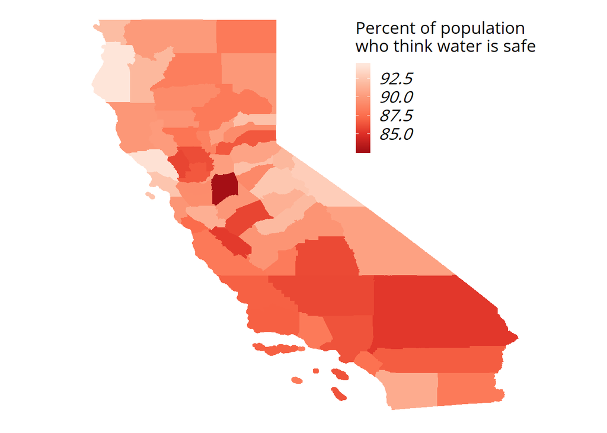

```r
ggplot(CA_counties_gg, aes(long, lat, group=group)) +
  geom_polygon(aes(fill = p_safe*100),colour = "transparent") +
  scale_fill_distiller("Percent of population \nwho think water is safe",palette = "Reds")+
  coord_equal() + plotThemeMap(base_size = 16) + theme(legend.position = c(0.8,0.8),legend.text = element_text(family="Open Sans"),
                                                       legend.title = element_text(family="Open Sans"))
```

Now, we want to compare the perception to reality. So we plot the percentage of the population who is affected by at least 1 violation

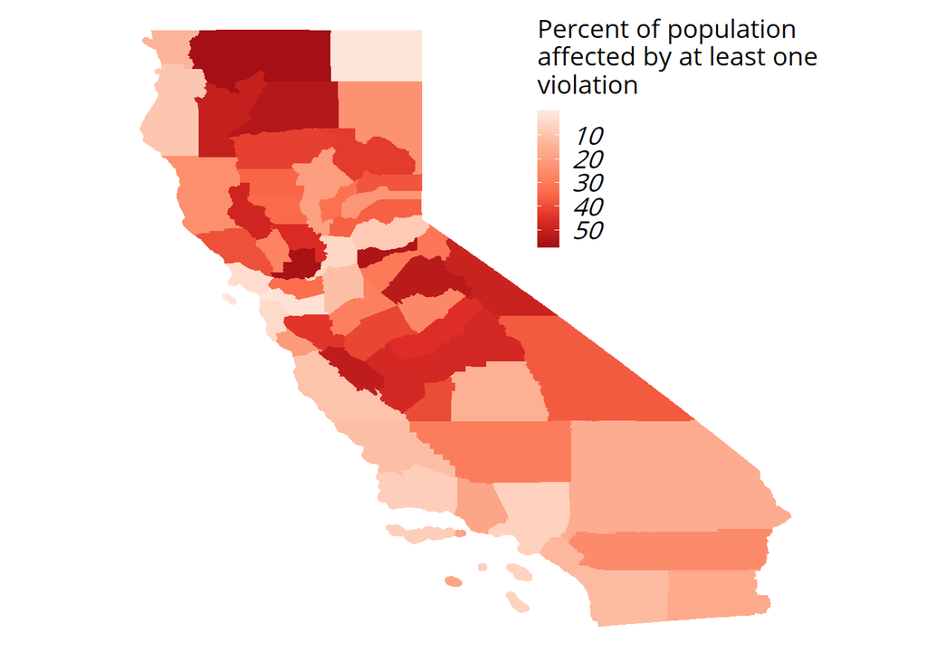

```r
ggplot(CA_counties_gg, aes(long, lat, group=group)) +
  geom_polygon(aes(fill = as.numeric(p_popaffected_1violation)),colour = "transparent") +
  scale_fill_distiller("Percent of population \naffected by at least one \nviolation", palette = "Reds", direction = -1, trans = "reverse")+
  coord_equal() + plotThemeMap(base_size = 16) + theme(legend.position = c(0.8,0.8),legend.text = element_text(family="Open Sans"),
                                                       legend.title = element_text(family="Open Sans"))
```

```r
ind_4counties <- which(CA_counties@data$FIP %in% c("6077","6005", "6085", "6039"))
CA_counties@data[ind_4counties,c("FIP","County.x","p_safe","p_popaffected_1violation")]
```

|  | FIP | County.x | p_safe | p_popaffected_1violation |
| --- | --- | --- | --- | --- |
| 3 | 6005 | Amador County, CA | 0.9219512 | 88.64% |
| 20 | 6039 | Madera County, CA | 0.9189189 | 56.75% |
| 39 | 6077 | San Joaquin County, CA | 0.8269231 | 1.62% |
| 43 | 6085 | Santa Clara County, CA | 0.9126638 | 52.39% |

Mapping safety perception for San Joaquin

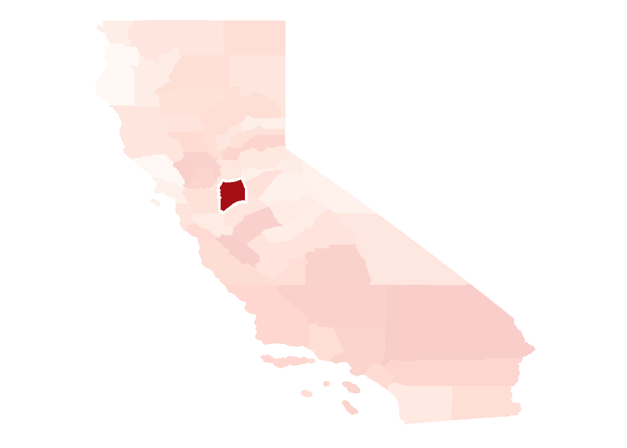

```r
ind_4counties <- which(CA_counties_gg$FIP %in% c("6077"))
ggplot() +
  geom_polygon(data = CA_counties_gg[-ind_4counties,], aes(long, lat, group=group,fill = p_safe*100),alpha = 0.25,colour = "transparent") +
  geom_polygon(data = CA_counties_gg[ind_4counties,],aes(long, lat, group=group,
                                                         fill = p_safe*100),colour = "white", size = 1) +
  scale_fill_distiller("% of population who\nthinks water is safe",palette = "Reds")+
  coord_equal() + plotThemeMap(base_size = 16) + theme(legend.position = "none")
```

Mapping violations for san joaquin

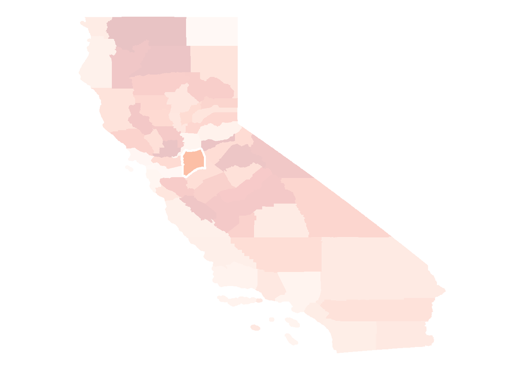

```r
ggplot() +
  geom_polygon(data = CA_counties_gg[-ind_4counties,], aes(long, lat, group=group,fill = as.numeric(p_popaffected_1violation)),alpha = 0.25,colour = "transparent") +
  geom_polygon(data = CA_counties_gg[ind_4counties,],aes(long, lat, group=group,
                                                         fill = as.numeric(p_popaffected_1violation)),colour = "white", size = 1) +
  scale_fill_distiller("% of population who\nthinks water is safe",palette = "Reds", direction = 1)+
  coord_equal() + plotThemeMap(base_size = 16) + theme(legend.position = "none")
```

Mapping safety for other 3 counties

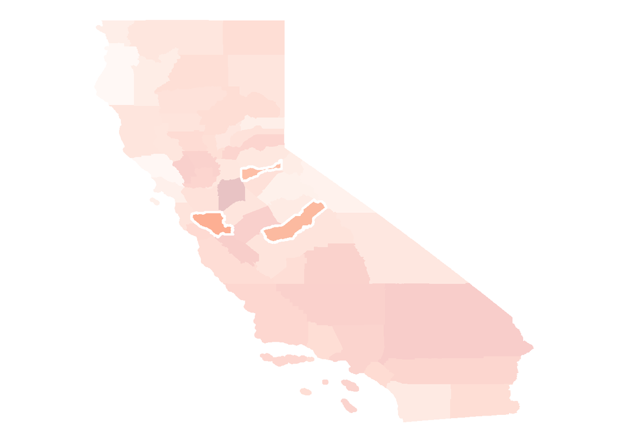

```r
ind_4counties <- which(CA_counties_gg$FIP %in% c("6005", "6085", "6039"))
ggplot() +
  geom_polygon(data = CA_counties_gg[-ind_4counties,], aes(long, lat, group=group,fill = p_safe*100),alpha = 0.25,colour = "transparent") +
  geom_polygon(data = CA_counties_gg[ind_4counties,],aes(long, lat, group=group,
                                                         fill = p_safe*100),colour = "white", size = 1) +
  scale_fill_distiller("% of population who\nthinks water is safe",palette = "Reds")+
  coord_equal() + plotThemeMap(base_size = 16) + theme(legend.position = "none")
```

Mapping violations for other three counties

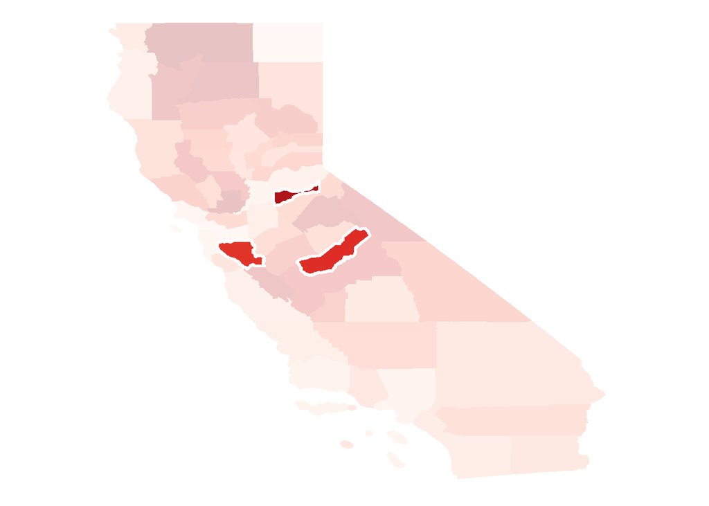

```r
ggplot() +
  geom_polygon(data = CA_counties_gg[-ind_4counties,], aes(long, lat, group=group,fill = as.numeric(p_popaffected_1violation)),alpha = 0.25,colour = "transparent") +
  geom_polygon(data = CA_counties_gg[ind_4counties,],aes(long, lat, group=group,
                                                         fill = as.numeric(p_popaffected_1violation)),colour = "white", size = 1) +
  scale_fill_distiller("% of population who\nthinks water is safe",palette = "Reds", direction = 1)+
  coord_equal() + plotThemeMap(base_size = 16) + theme(legend.position = "none")
```

## Understanding how perception affects consumption

Now we want to see if perception affects our actions. So we compare perception to spending on water bottles (we’d expect people who think the tap water to be unsafe to buy more water bottles)

Let’s take a look at the relationship between the water bottle spending and people’s perception

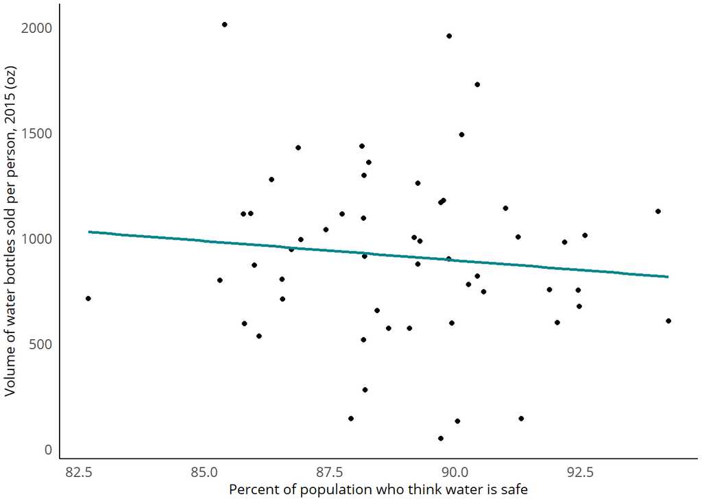

```r
ind <- which.max(CA_counties@data$vol_cap)
ggplot(CA_counties@data[-ind,], aes(y = vol_cap,x = p_safe*100))+
  geom_point(na.rm=TRUE)+
  stat_smooth(method = "lm", alpha = 1, se = F, col = "turquoise4", na.rm=TRUE)+
  labs(y = "Volume of water bottles sold per person, 2015 (oz)",
       x = "Percent of population who think water is safe")+
  scale_color_manual(values = c("tomato3","black"))+
  plotThemeDesign()+theme(legend.position='none', axis.title = element_text(family="Open Sans"), axis.text = element_text(family="Open Sans"))
```

If we pull out our highighted counties…

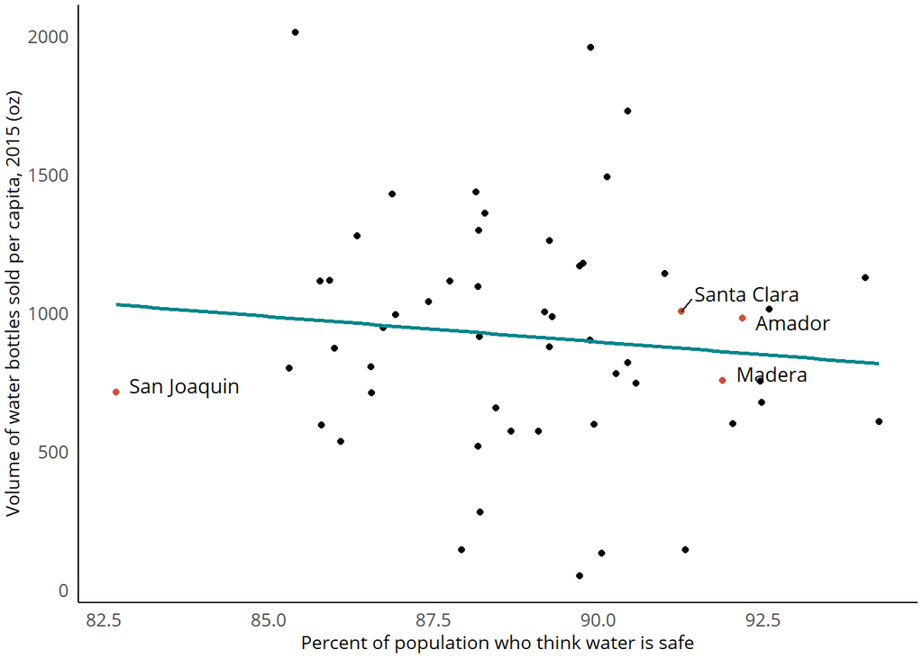

[figure not shown]

[figure not shown]

```r
ind_4counties <- which(CA_counties@data$FIP %in% c("6077", "6005", "6085", "6039"))
ind <- which.max(CA_counties@data$vol_cap)
CA_counties@data$county_simple <- stringr::str_split(as.character(CA_counties@data$County.x), " County", simplify = T)[,1]
CA_counties@data$highlight = "regular"; CA_counties@data$highlight[ind_4counties] = "highlight"
ggplot(CA_counties@data[-ind,], aes(y = vol_cap,x = p_safe*100))+
  geom_point(na.rm=TRUE, aes(color = highlight))+
  geom_text_repel(data = CA_counties@data[ind_4counties,],aes(label = county_simple),nudge_x = 0.2,nudge_y = 25,hjust=0,
                  direction = "y",family="Open Sans")+
  stat_smooth(method = "lm", alpha = 1, se = F, col = "turquoise4", na.rm=TRUE)+
  labs(
       y = "Volume of water bottles sold per capita, 2015 (oz)",
       x = "Percent of population who think water is safe")+
  scale_color_manual(values = c("tomato3","black"))+
  plotThemeDesign()+theme(legend.position='none', axis.title = element_text(family="Open Sans"),
                          axis.text = element_text(family="Open Sans"))
```

## How to track perception?

Okay, so now that we know that this is a marginal correlation between perception and consumption, how can cities track perception better (Without having to survey people all the time)

Here we explore google searches as a proxy for perception. Google search data is organized by metro. So we read in the search popularity data by metro area. Here we aggregate the searches for the following terms:

- water quality
- water purification
- tap water
- safe water
- drinking water
- water filter

```r
search_dat <- read.csv(file = "data/raw_data/search_data.csv")
head(search_dat)
```

|  | DMA | water_quality_2018 | Water_purification | tap_water | safe_Water | drinking_water | water_filter | average | p_safe |
| --- | --- | --- | --- | --- | --- | --- | --- | --- | --- |
| 1 | Medford-Klamath Falls OR | 6 | 14 | 12 | 6 | 9 | 7 | 9.00000 | 0.9005236 |
| 2 | Reno NV | 11 | 15 | 23 | 16 | 10 | 10 | 14.16667 | 0.9091160 |
| 3 | Yuma AZ-El Centro CA | NA | 59 | NA | NA | 32 | 30 | 40.33333 | 0.8818182 |
| 4 | Bakersfield CA | 24 | 58 | 62 | 73 | 80 | 77 | 62.33333 | 0.8592965 |
| 5 | Fresno-Visalia CA | 30 | 63 | 62 | 70 | 91 | 75 | 65.16667 | 0.8843572 |
| 6 | Los Angeles CA | 24 | 81 | 83 | 67 | 82 | 78 | 69.16667 | 0.8658583 |

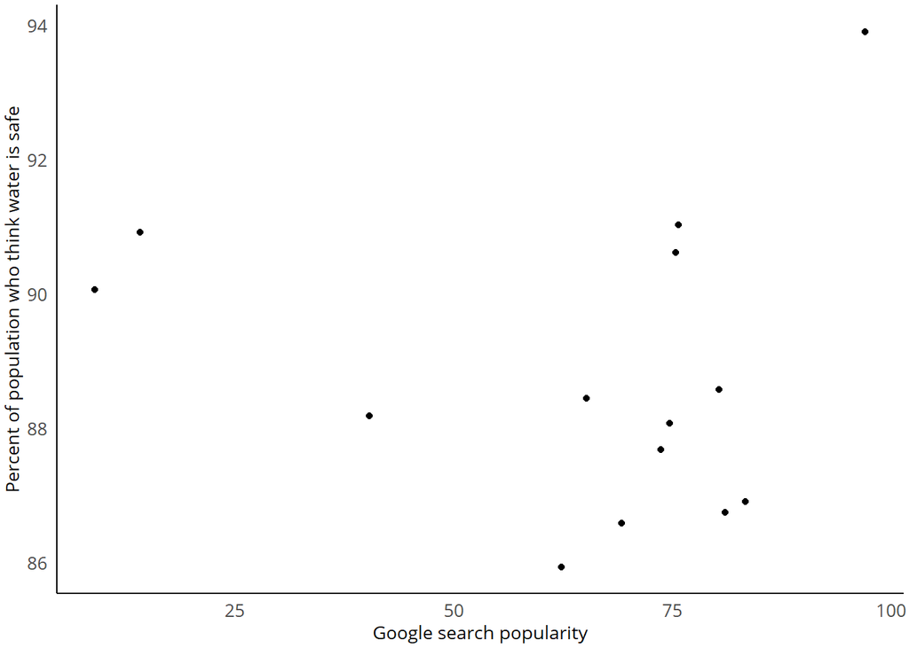

```r
ggplot(search_dat, aes(x = average,y = p_safe*100))+
  geom_point()+
  labs(
       x = "Google search popularity",
       y = "Percent of population who think water is safe")+
  plotThemeDesign()+theme(legend.position='none', axis.title = element_text(family="Open Sans"),
                          axis.text = element_text(family="Open Sans"))
```

## Code for calculating perception

```r
print("test perception")
library(dplyr)
library(future)
library(doFuture)
setwd("/home/users/sloos/DP3-analysis")
# perception model for batch processing
CA_county_dat <- readRDS("data/output_data/CA_county_demog.rds")
AHS_perc_dat <- readRDS("data/output_data/AHS_perception_dat.rds")
# function to calculate the percentage of each demographic given an array
perc_calc <- function(array_samp){
  p_white <- (array_samp %>% filter(HHRACE ==1) %>% filter(HHSPAN == 2) %>% summarise(p = n()))[1,1]/nrow(array_samp)
  p_hisp <- (array_samp %>% filter(HHRACE ==1) %>% filter(HHSPAN == 1) %>% summarise(p = n()))[1,1]/nrow(array_samp)
  p_black <- (array_samp %>% filter(HHRACE ==2) %>% summarise(p = n()))[1,1]/nrow(array_samp)
  p_other <- (array_samp %>% filter(HHRACE >= 3) %>% summarise(p = n()))[1,1]/nrow(array_samp)
  p_female <- (array_samp %>% filter(HHSEX ==2) %>% summarise(p = n()))[1,1]/nrow(array_samp)
  p_citizen <- (array_samp %>% filter(HHCITSHP !=5) %>% summarise(p = n()))[1,1]/nrow(array_samp)
  p_hsgrad <- (array_samp %>% filter(HHGRAD %in% seq(39,47)) %>% summarise(p = n()))[1,1]/nrow(array_samp)
  p_homeowner <- (array_samp %>% filter(TENURE ==1) %>% summarise(p = n()))[1,1]/nrow(array_samp)
  # p_mobile <- (array_samp %>% filter(BLD ==1) %>% summarise(p = n()))[1,1]/nrow(array_samp)
  # p_pubhs <- (array_samp %>% filter(HUDSUB == 1) %>% summarise(p = n()))[1,1]/nrow(array_samp)
  dat <- as.data.frame(cbind(p_white, p_hisp, p_black, p_other, p_female, p_citizen, p_hsgrad, p_homeowner))
  dat = dat*100
  return(dat)
}

registerDoFuture()
cl<- parallel::makeCluster(as.numeric(Sys.getenv("SLURM_NTASKS")))
future::plan(tweak(cluster, workers = cl))

system.time(
  p_safe <- foreach(i=1:nrow(CA_county_dat), .combine="rbind") %dopar% {
    real_county <- CA_county_dat[i,-c(1,10,11)]
    # build initial fake county (using 10 rows of the AHS survey)
    ind <- sample(nrow(AHS_perc_dat), 10, replace = F)
    d1 =1000
    j=1
    while (d1 > 30 && j < 5000) { # 5% error for each var
      fake_county1 <- perc_calc(AHS_perc_dat[ind,])
      # calculate distance between vectors
      d1 = dist(rbind(real_county, fake_county1), method = "euclidean")[1]
      # randomly add another row to vec 2
      ind2 <- sample(nrow(AHS_perc_dat),1)
      fake_county2 = perc_calc(AHS_perc_dat[append(ind,ind2),])
      d2 = dist(rbind(real_county, fake_county2), method = "euclidean")[1]
      if(d2 <d1){
        fake_county1 = fake_county2
        ind = append(ind,ind2)
      }
      j=j+1
    }
    # calculate the percentage who think water is safe
    p_safe = length(which(AHS_perc_dat[ind,]$WATSAFE ==1))/length(ind)
    d1_vec = d1
    dat = cbind(p_safe, d1_vec)
  }
)

p_safe <- data.frame(p_safe, row.names = row.names(CA_county_dat))
p_safe <- cbind(CA_county_dat, p_safe)
# save
date <- format(Sys.Date(), "%m%d%y")
saveRDS(p_safe, paste0("data/output_data/CA_county_perception_",date,".rds"))
```